# Statistical Thinking

Elementary Statistics

MTH-161D | Spring 2025 | University of Portland

January 15, 2025

# Objectives

- **Introduce the concept of statistical thinking**
- **Communicate the course learning outcomes**
- **Activity: Reading and Writing Exercises**

# Data Science

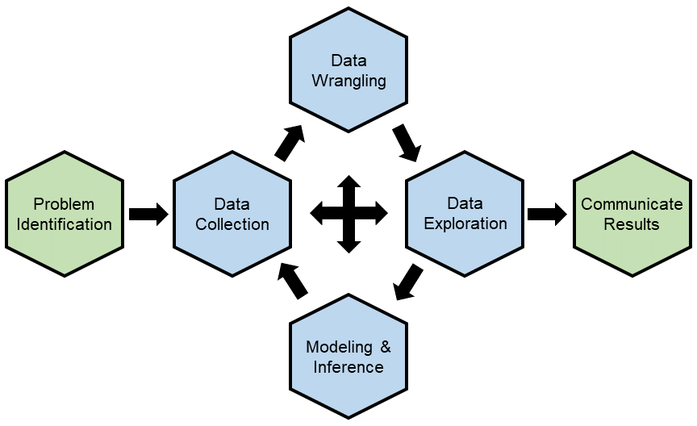

The Data Science Life Cycle

# Statistical Thinking: An Overview

**What is statistical thinking?**

A way of understanding the world through data.

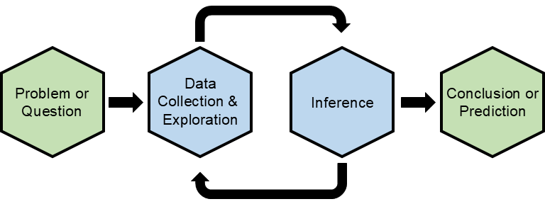

Statistical Thinking in the Data Science Life Cycle

$\star$ Statistical thinking is our guiding principle as we learn statistical concepts and techniques.

# Example 1: Statistical Question

*Question:* **What is the crime rate in Portland, OR?**

This question requires:

1. Data collection from a representative sample of neighborhoods in Portland.
2. Statistical analysis to estimate the average crime rate.

# Example 1: Preparation

*Question:* **What is the crime rate in Portland, OR?**

The analysis anticipates:

1. **Variability.** No two neighborhoods will produce exactly the same result.
2. **Uncertainty.** Because data varies, we’re often unsure about the “true” answer to the question.
3. **Context.** Numbers alone don’t tell the whole story. You need to consider the situation, the method of data collection, and any potential biases.

# Example 1: Data Visualization

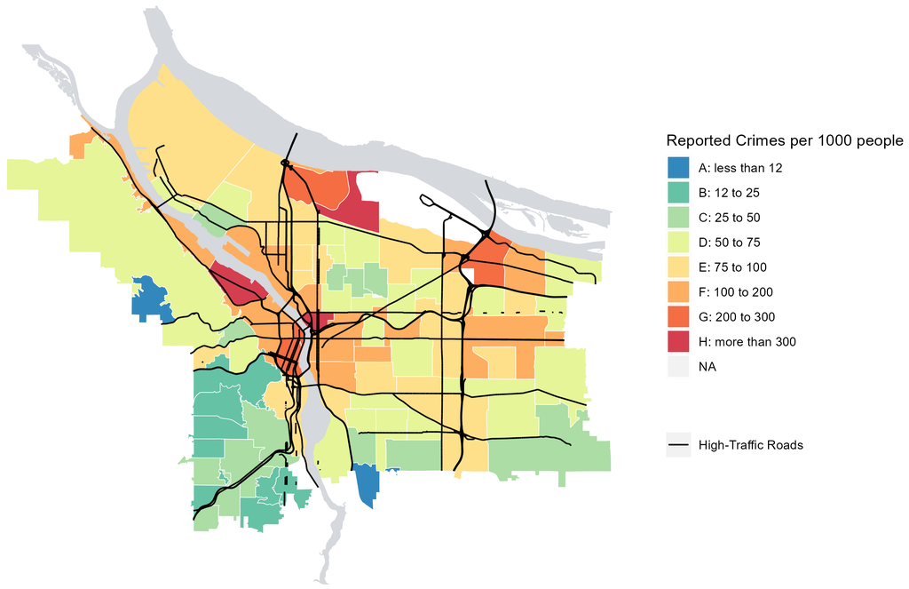

Portland crime rates in fiscal year 2020 to 2021.

# Example 1: Confounders

*Follow-up question:* **What types of crimes are usually reported?**

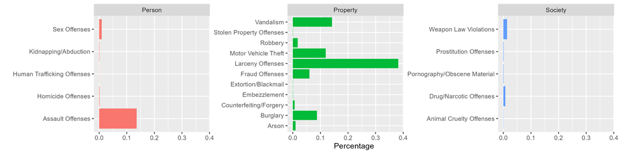

Portland types of crimes in year 2020 to 2021.

# Statistical Thinking: Steps

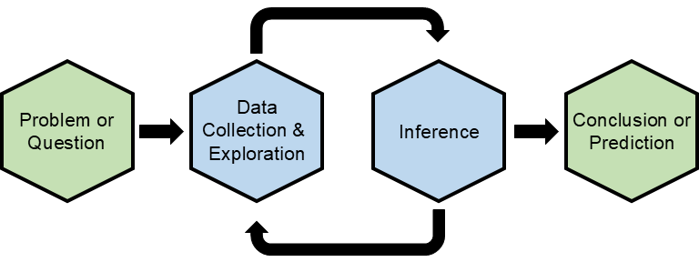

Statistical Thinking in the Data Science Life Cycle

**Steps in Statistical Thinking:**

1. Ask a question or identify a problem
2. Collect data, understand variability, identify patterns and relationships
3. Apply statistical analysis
4. Evaluate results and make a conclusion or predict an outcome

# Course Learning Outcomes (1/2)

- **Data Foundation:**
  - *Structure:* Understand data types, formats, and relationships.
  - *Collection:* Explore sampling methods and ethical considerations.
  - *Limitations:* Recognize biases, errors, and missing data impacts on analysis.
- **Statistical Analysis:**
  - *Univariate:* Analyze single variables.
  - *Bivariate:* Explore relationships between pairs of variables.
  - *Multivariate:* Analyze complex interactions among multiple variables.

The full course learning outcomes and objectives is in the Syllabus.

# Course Learning Outcomes (2/2)

- **Data Exploration & Presentation:**
  - *Visualization:* Create effective graphs to communicate insights.
  - *Descriptive Stats:* Calculate measures of central tendency and variability.
- **Foundational Concepts:**
  - *Probability:* Grasp core principles.
  - *Critical Thinking:* Evaluate claims, identify biases, and make data-driven conclusions.
- **R Programming:**
  - *Data Preparation:* Clean, transform, and prepare data for analysis.
  - *Statistical Modeling:* Implement statistical tests and regressions.
  - *Visualization:* Create informative data visualizations.

The full course learning outcomes and objectives is in the Syllabus.

# Activity: Reading and Writing Exercises

**Scenario:** Researchers conducted a study to understand whether drinking coffee impacts productivity at work. They collected data on how much coffee people drink daily and how productive they feel during their workday. The study examined whether there is a consistent pattern between coffee consumption and productivity levels.

**Discussion Questions:** Write your individual answers for the following questions on paper, then discuss them with your peers.

1. What is the main focus of the study?
2. How might coffee consumption affect productivity, based on your intuition?
3. What could a strong relationship between coffee consumption and productivity suggest for coffee drinkers?
4. What other factors (confounders) might influence both coffee consumption and productivity? How could these affect the study’s conclusions?
5. If the study finds a meaningful connection, what practical advice could it offer to workers?

# References

Diez, D. M., Barr, C. D., & Çetinkaya-Rundel, M. (2012). *OpenIntro statistics* (4th ed.). OpenIntro. https://www.openintro.org/book/os/